# 红葡萄酒质量分析 by ZJW

# 定稿图与总结

### 绘图一

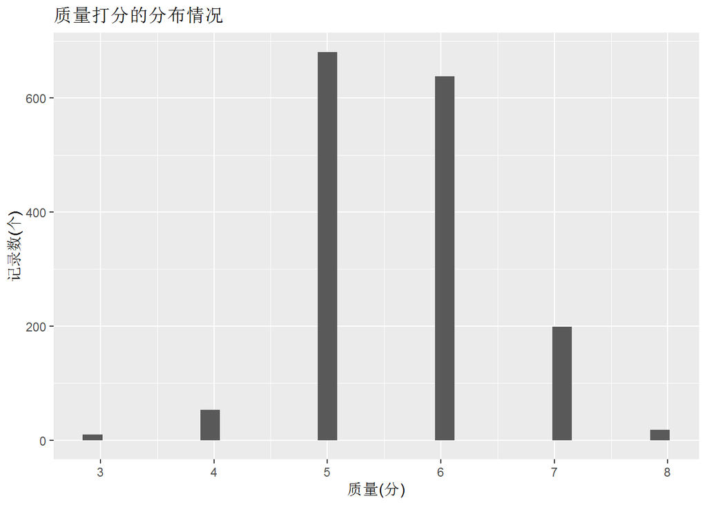

### 描述一

质量打分指标，最小值是3，最大值是8，中位数6，成正态分布。

### 绘图二

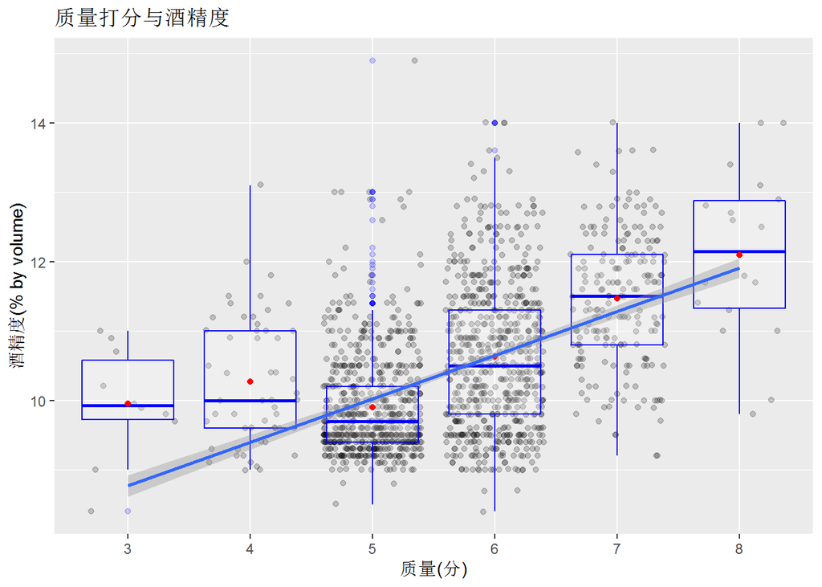

### 描述二

可以看到酒精并不是完全和质量打分线性相关的。 从5到8分的时候，酒精含量是不断上升的。 3到4分的时候，酒精含量也是在上升的。 但是，4分到5分，酒精含量存在一个落差。 另外可以发现的是，数据集中的数据大部分都是落在5分和6分中的，这里符合正态分布。

### 绘图三

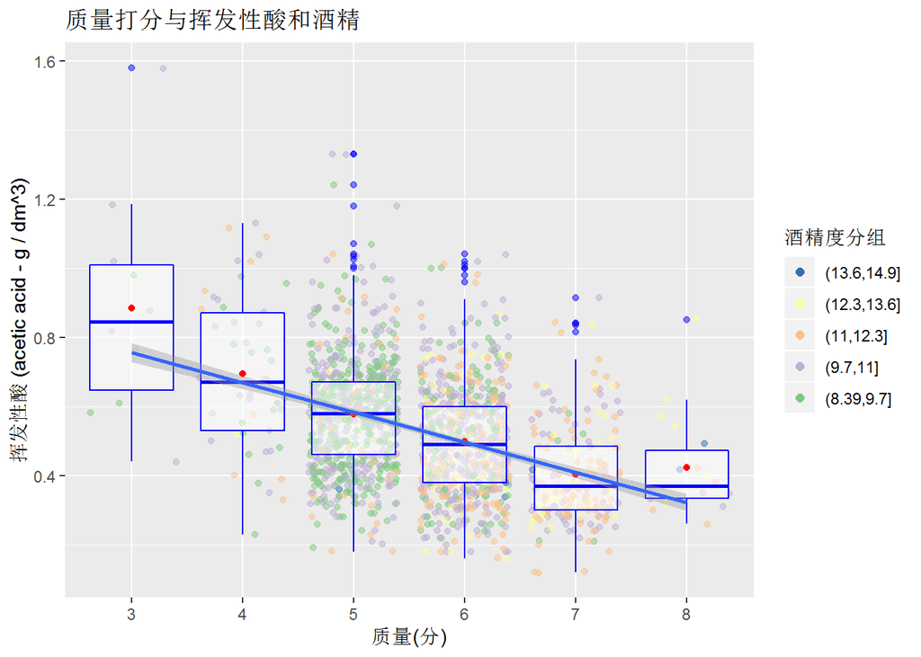

# 反思

这是一个拥有1599条记录，共12个变量（包含打分）的红葡萄酒数据集。其中我认为最终要的指标是酒精浓度、挥发性酸含量和质量打分。打分是范围0到10分的打分指标。该数据集质量打分最小值是3，最大值是8，中位数6，成正态分布。除此之外，固定酸与硫酸盐也是重要指标，因为他们会对一级指标产生影响。

### 参考链接：

> https://www.rdocumentation.org/packages/GGally/versions/1.4.0/topics/ggpairs  
> https://www.rdocumentation.org/packages/base/versions/3.6.1/topics/cut https://stackoverflow.com/questions/34983118/how-do-i-create-a-copy-of-a-data-frame-in-r/51143421 https://stackoverflow.com/questions/6286313/remove-an-entire-column-from-a-data-frame-in-r https://sebastiansauer.github.io/figure_sizing_knitr/ https://daringfireball.net/projects/markdown/syntax#list https://www.zhihu.com/question/20773293